# Problem statement

The (potential) disruptive effect that the energy transition has on the Dutch society creates a needs to precisely identify and understand the precarious publics that are - by not adopting – targeted by the process of innovating to a carbon-free society. According to Rogers, late adopters are stereotypically perceived as being traditional, uneducated, resistant to change, low economic resources, and that may become a self-fulfilling prophecy [@rogers_1983, p. 107; @merton_1995]. However, the choice to adopt is also not only a matter of economic resources. A division of adopters vs. not adopters of new sustainable energy technology’s merely on the availability of recourses neglects other motivations [@Wyatt_2003]. This reasoning ignores that technological innovation is always an interplay between material and social landscapes [@jasanoff_kim_2015]. Due to both the risk and uncertainty of climate change, people use different discourses to depict the future [@Cook_2018]. This process, which Jasanoff calls “co-production,” is about how knowledge about the world is inseparable from how we choose to live in it [-@jasanoff_2004]. The adoption of innovation is, in that manner, influenced by individual and public visions of the desirable future in terms of social practices, identities, norms, and instruments. These imaginaries are diverse, and thereby both innovators and non-innovators can be divided into numerous publics for innovation discourse. Thus the economic resources of adopters are maybe not a motivator for innovation increasing the possibility of adoption on a continues scale as suggested by research [@Bernards_2018], but more as an enabler with a threshold from where the investment becomes possible. Sociotechnical imaginaries shape the future of the transition to a sustainable future, understanding this imaginaries for the non-adopters is key in understanding why this group is not innovating.

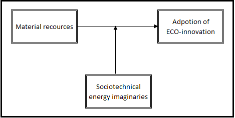

Conceptual model adaptation of sustainable technology

```r
knitr::include_graphics("C:/Users/602956/Desktop/Studie/Thesis/Sociology thesis/fig/ConceptueelModel.png", dpi = 108)
```

The real decision making for the investment in ECO-innovation is an interplay between the natural resources and the social world of the adopter, the effects this interplay has on the possibility of a household (not) to invest in sustainable innovations will be investigated in this article. Only the investigation of the interplay between these concepts will create an understanding of why household are not adopting new technology. This understanding makes possible public issues in the transition to sustainable energy visible and can thereby help in creating a more inclusive framework for transitions. The conceptual model is shown in figure @ref(fig:Conspt). Built from the findings from Rogers that laggards non-adopters are not just opposing to change, but can experience real boundaries in adopting innovation [@rogers_1983], the research question in this article is the following:

*What is the role of sociotechnical energy imaginaries, like climate apocalypse or sustainable future, in the adoption of ECO-innovation by households in the Dutch society?*

This question is investigated in two parts. The first part of the research in this article is about identifying different social groups in the adoption of innovation based on natural resources, by an empirical study of the distribution of ECO-innovations in the Dutch landscape [@James_1997]. By investigating the material factors, such as annual income, house ownership and characteristic of the house itself. By studying these factors, we create more insight into the factors that enable a household to adopt new technology. The social systems that are identified as not adopting ECO-innovation are further investigated in the second part of the article. This second part is an exploration of the normative framework of the social network of a household. This part is done by conducting extensive interviews amongst identified groups. Together these studies create understanding about why people are not adopting ECO-innovation and evaluates if the struggles for sustainability are (re)making urban spaces [@Jhagroe_2016].